# Linear Regression

All these assumptions and potential problems can be checked by producing some diagnostic plots visualizing the residual errors.

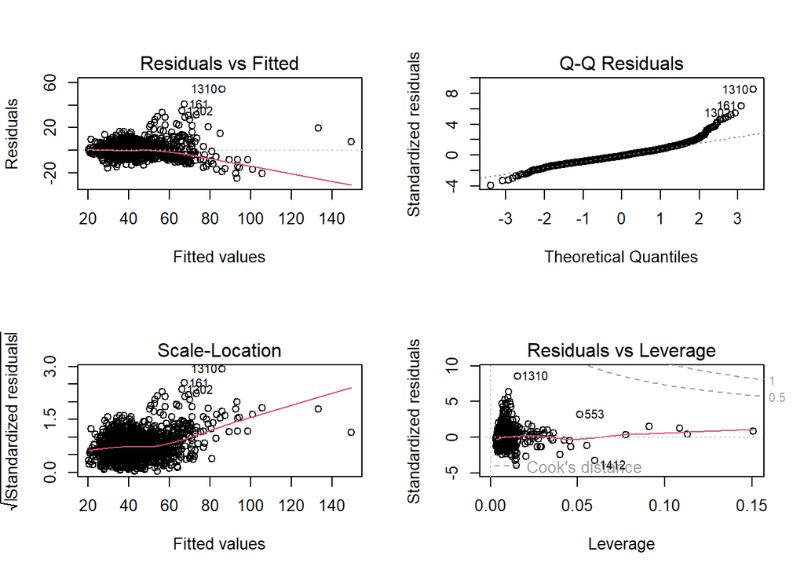

```r
par(mfrow=c(2,2))
plot(lm_full)
```

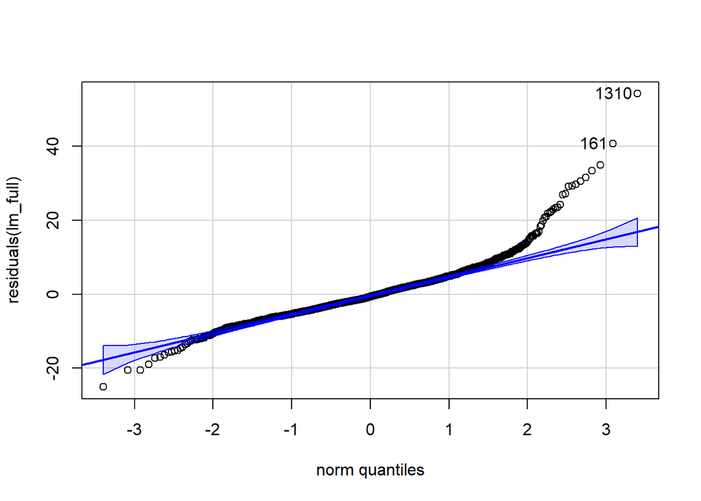

```
## [1] 1310  161
```

```r
qqPlot(residuals(lm_full))
```

Much clearly the qqPlot tells that the data the residuals are not normally distributed indeed are moderately right skewed. Thus we can’t trust the p-values and the estimation of the coefficients.

For curiosity we analyse in a better and much detailed plot the presence of influential points.

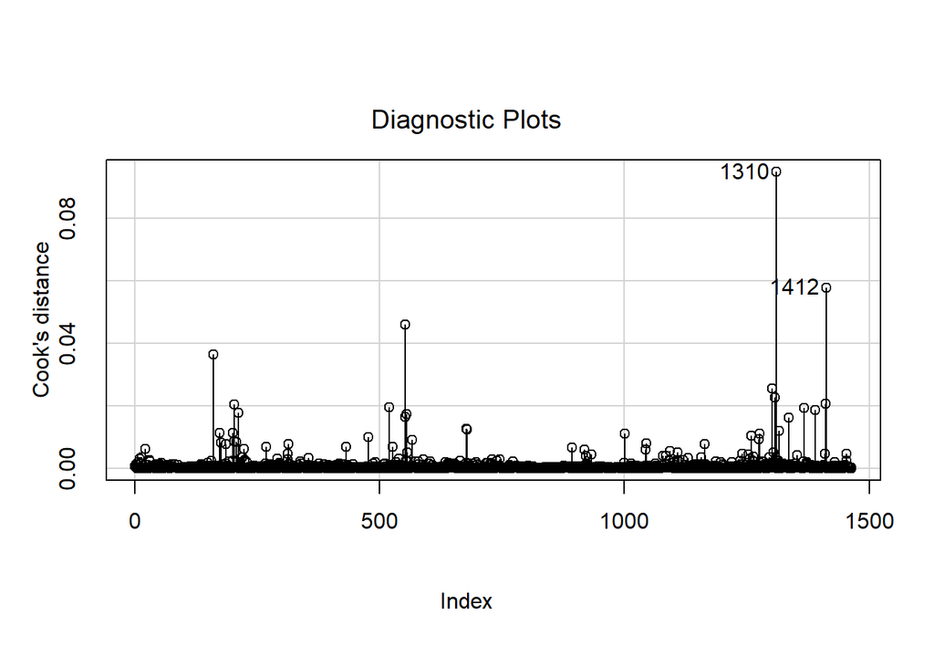

```r
influenceIndexPlot(lm_full, vars = "Cook")
```

For the vast majority of observations, Cook’s distance is close to zero, indicating that most points have minimal impact on the fitted model. Cook’s distance is significantly higher in a few examples (1310 and 1412), suggesting possibly significant outliers that should be investigated.

Here instead we have a look at all plots of residuals vs predictors and again the plot of residuals vs fitted values that we already see.

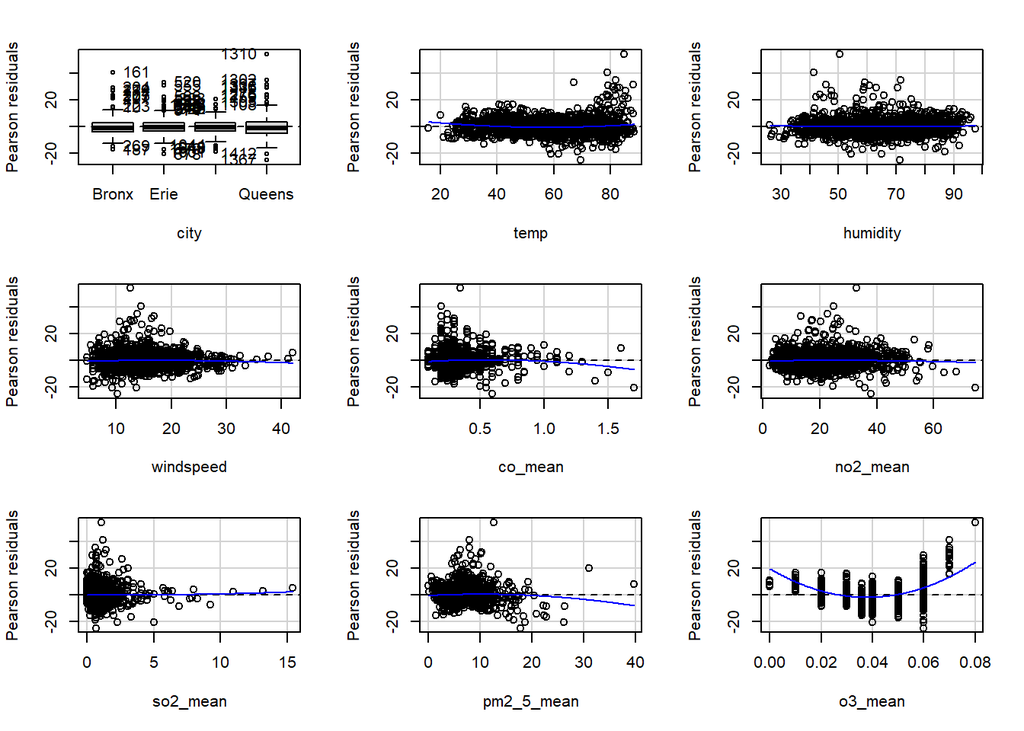

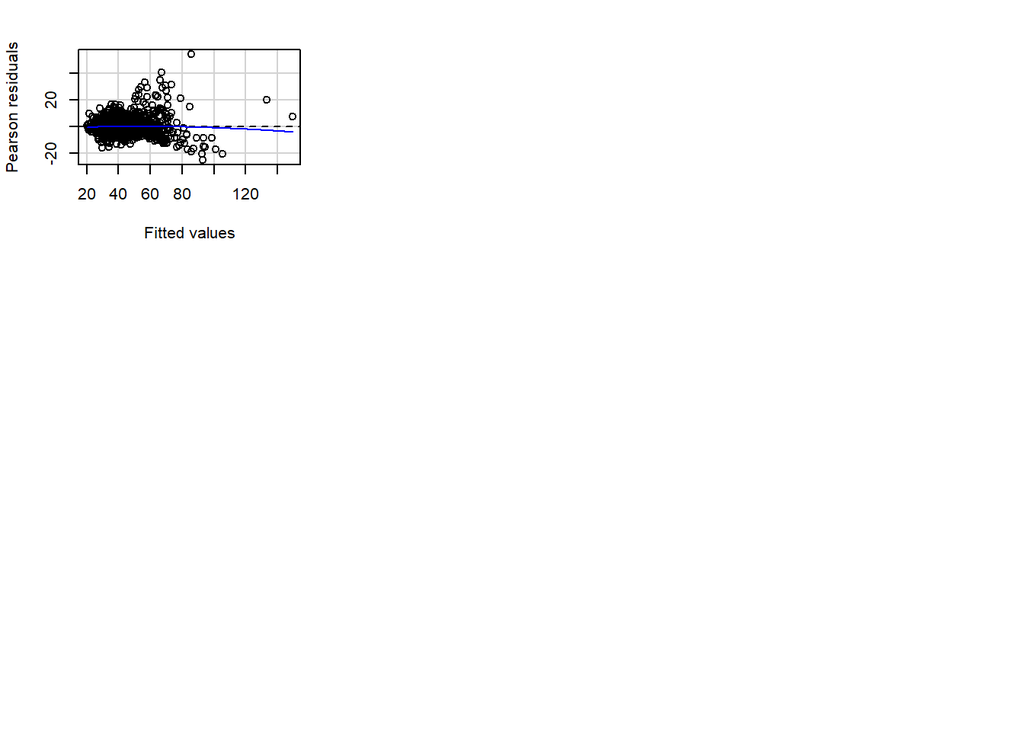

```
##            Test stat Pr(>|Test stat|)
## city
## temp          3.5802        0.0003546 ***
## humidity      0.6602        0.5092314
## windspeed    -0.8680        0.3855451
## co_mean      -2.4885        0.0129408 *
## no2_mean     -0.7923        0.4283309
## so2_mean      0.5767        0.5642303
## pm2_5_mean   -2.0259        0.0429558 *
## o3_mean      24.0804        < 2.2e-16 ***
## Tukey test   -1.1032        0.2699359
## ---
## Signif. codes:  0 '***' 0.001 '**' 0.01 '*' 0.05 '.' 0.1 ' ' 1
```

```r
residualPlots(lm_full)
```

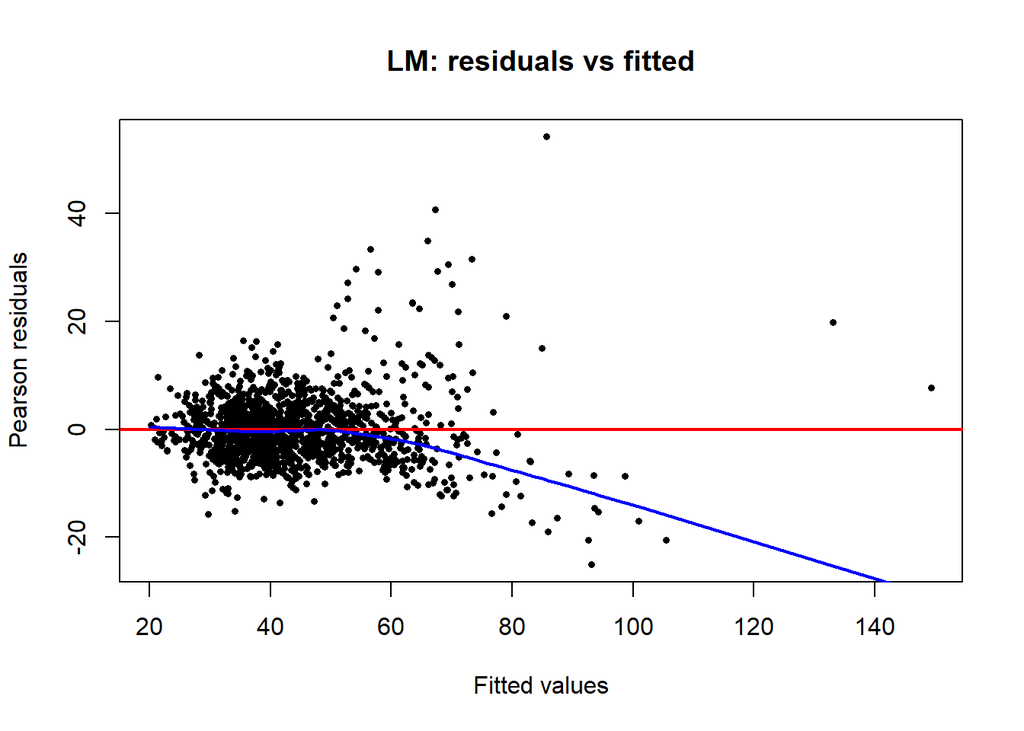

```r
rstd_lm_full <- residuals(lm_full, type = "pearson")
yhat_lm_full <- fitted(lm_full)
n_lm_full   <- length(rstd_lm_full)

# 2) residuals vs fitted values
ok <- is.finite(yhat_lm_full) & is.finite(rstd_lm_full)
plot(yhat_lm_full[ok], rstd_lm_full[ok], pch=16, cex=0.6,
     xlab="Fitted values", ylab="Pearson residuals",
     main="LM: residuals vs fitted")
abline(h=0, col="red", lwd=2)
lines(lowess(yhat_lm_full[ok], rstd_lm_full[ok]), col="blue", lwd=2)
```

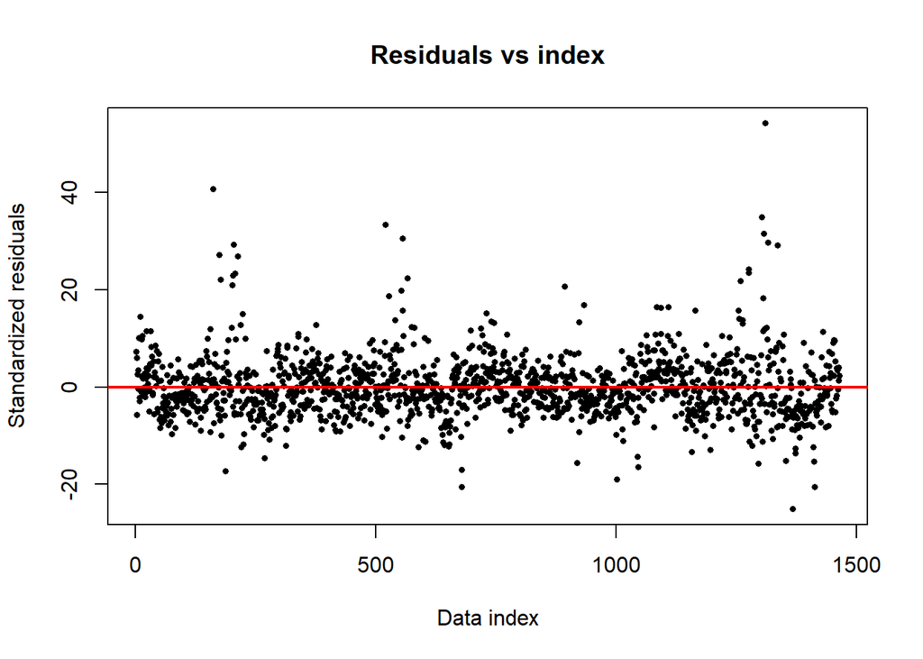

```r
# 1) residuals vs data index
plot(1:n_lm_full, rstd_lm_full, pch=16, cex=0.6,
     xlab="Data index", ylab="Standardized residuals",
     main="Residuals vs index")
abline(h=0, col="red", lwd=2)
```

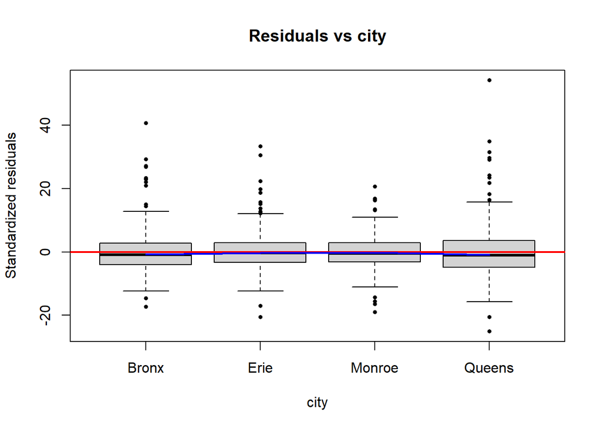

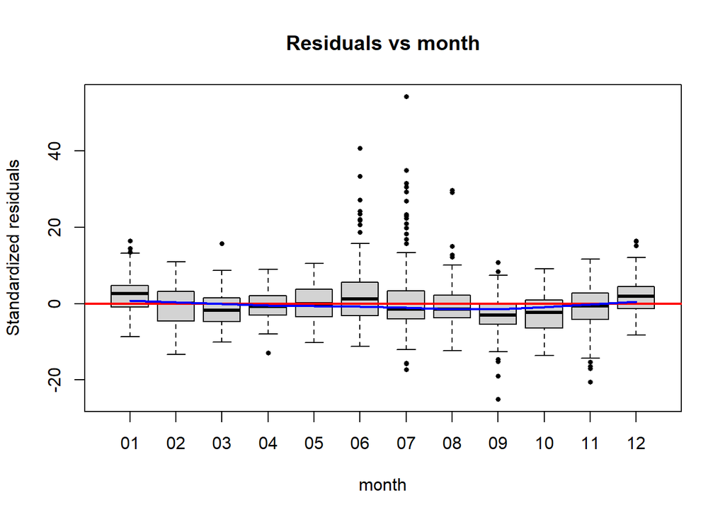

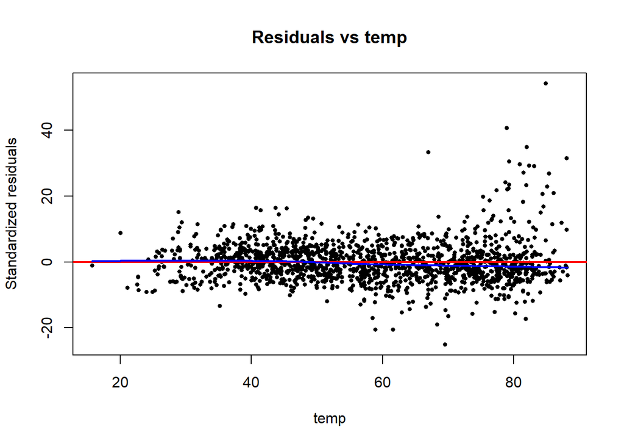

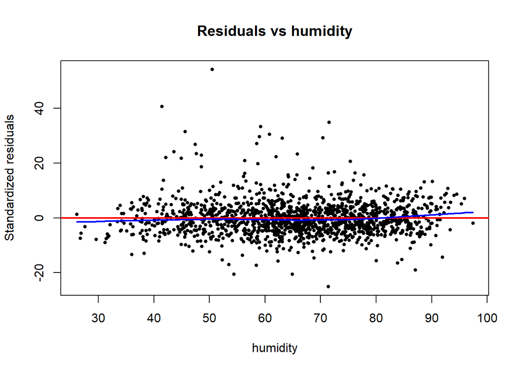

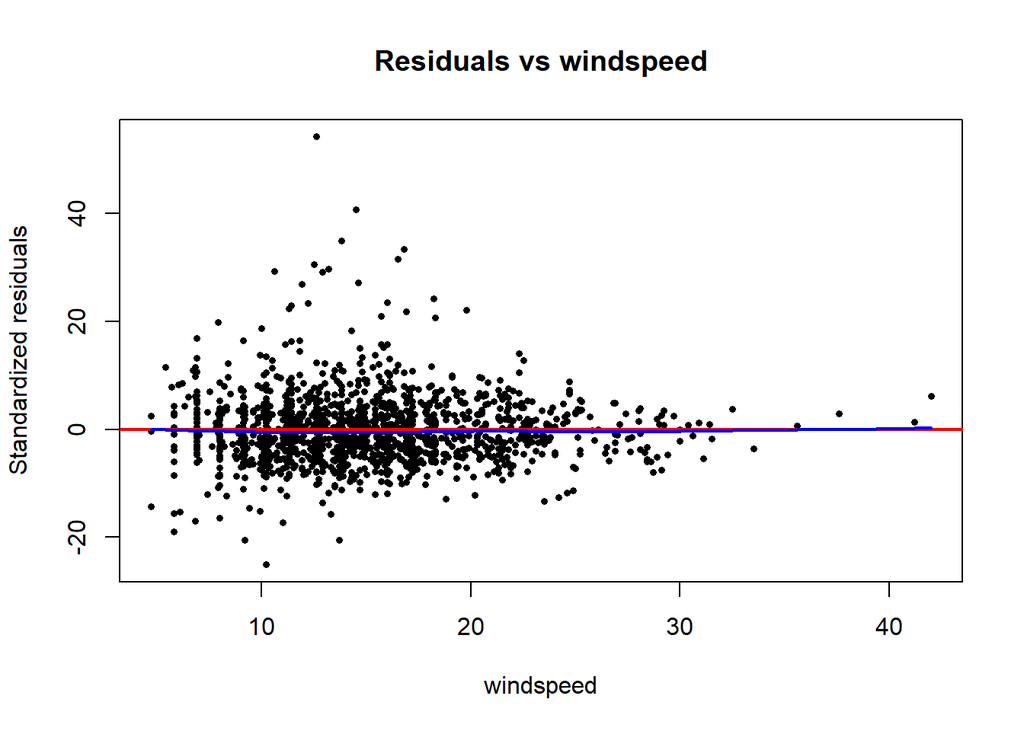

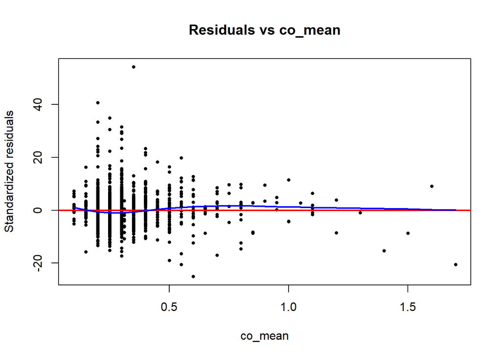

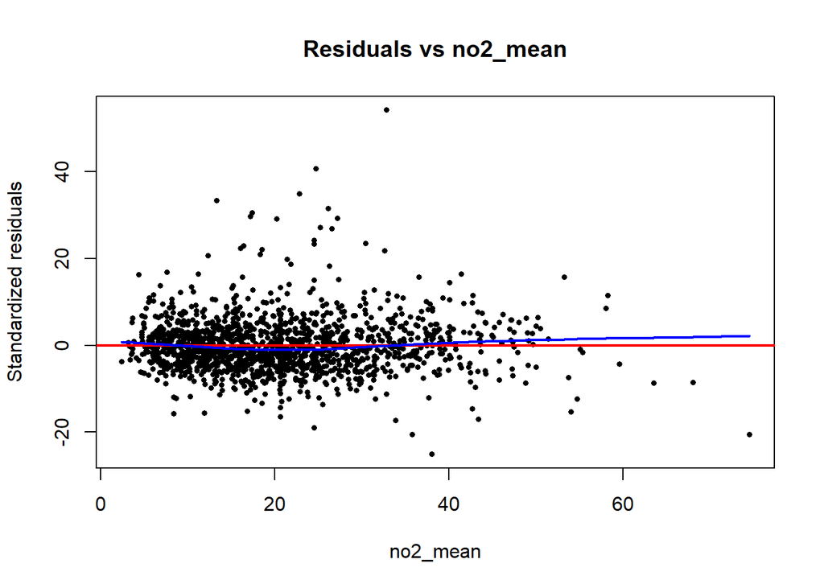

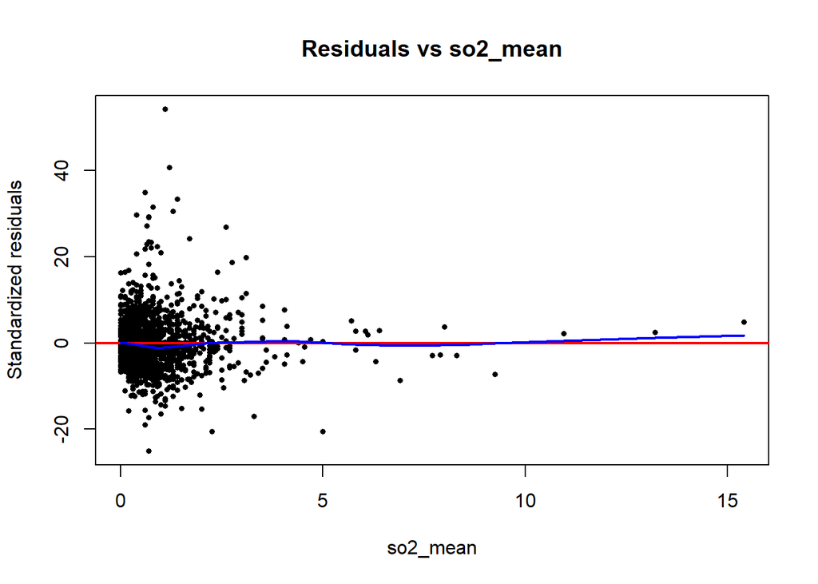

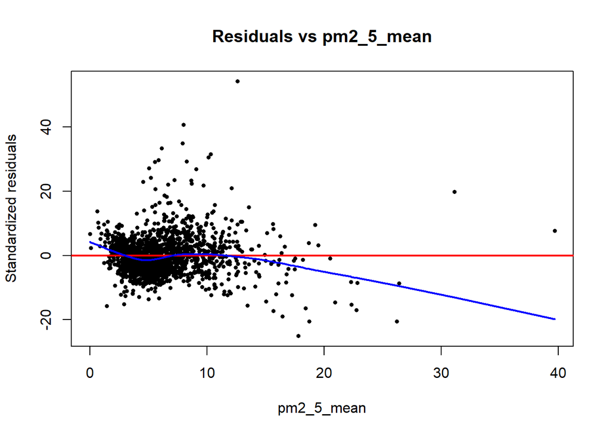

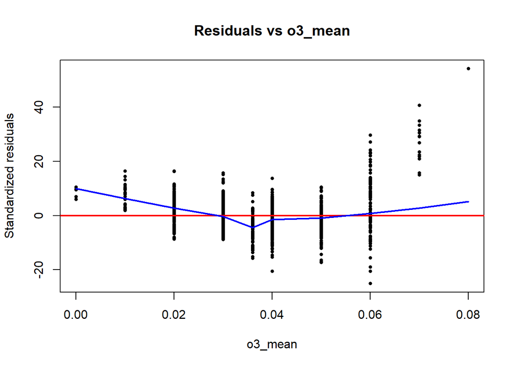

```r
# 3) residuals vs predictors (one by one)
train_full$city <- factor(train_full$city)
Xcols <- c("city", "month", "temp","humidity","windspeed",
           "co_mean","no2_mean","so2_mean","pm2_5_mean","o3_mean")

for (x in Xcols) {
  xx <- train_full[[x]]
  ok <- is.finite(xx) & is.finite(rstd_lm_full)

  plot(xx[ok], rstd_lm_full[ok], pch=16, cex=0.6,
       xlab=x, ylab="Standardized residuals",
       main=paste("Residuals vs", x))
  abline(h=0, col="red", lwd=2)
  lines(lowess(xx[ok], rstd_lm_full[ok]), col="blue", lwd=2)
}
```